# Malware file headers dataset

### Source: https://www.kaggle.com/datasets/fanbyprinciple/file-pe-headers?resource=download

Given a dataset of file PE headers, some of which are malware, is it possible to mathematically model and detect malicious files? For reference, here is the entire MS-DOS header in detail; knowledge kindly shared by [Osand Amalith](https://osandamalith.com/2020/07/19/exploring-the-ms-dos-stub/):

```python
#define IMAGE_DOS_SIGNATURE                 0x5A4D      // MZ
#define IMAGE_NT_SIGNATURE                  0x00004550  // PE00
typedef struct _IMAGE_DOS_HEADER {      // DOS .EXE header
    WORD   e_magic;                     // Magic number
    WORD   e_cblp;                      // Bytes on last page of file
    WORD   e_cp;                        // Pages in file
    WORD   e_crlc;                      // Relocations
    WORD   e_cparhdr;                   // Size of header in paragraphs
    WORD   e_minalloc;                  // Minimum extra paragraphs needed
    WORD   e_maxalloc;                  // Maximum extra paragraphs needed
    WORD   e_ss;                        // Initial (relative) SS value
    WORD   e_sp;                        // Initial SP value
    WORD   e_csum;                      // Checksum
    WORD   e_ip;                        // Initial IP value
    WORD   e_cs;                        // Initial (relative) CS value
    WORD   e_lfarlc;                    // File address of relocation table
    WORD   e_ovno;                      // Overlay number
    WORD   e_res[4];                    // Reserved words
    WORD   e_oemid;                     // OEM identifier (for e_oeminfo)
    WORD   e_oeminfo;                   // OEM information; e_oemid specific
    WORD   e_res2[10];                  // Reserved words
    LONG   e_lfanew;                    // File address of new exe header
  } IMAGE_DOS_HEADER, *PIMAGE_DOS_HEADER;
```

It feels very, *very* refreshing to encounter C in this unstimulating Python-dominated world.

# Libraries

```python
import numpy as np
import pandas as pd
import seaborn as sns
import statsmodels.api as sm
import matplotlib.pyplot as plt
import os

from scipy import stats
from sklearn.preprocessing import StandardScaler
from sklearn.decomposition import PCA
from sklearn.feature_selection import RFE
from sklearn.model_selection import train_test_split
from sklearn.metrics import confusion_matrix, accuracy_score, classification_report, roc_auc_score, roc_curve, auc
from statsmodels.stats.outliers_influence import variance_inflation_factor

from sklearn.svm import SVC
from sklearn.tree import DecisionTreeClassifier
from sklearn.linear_model import LogisticRegression

os.getcwd()
```

```
'/home/rahuls/Documents/INSOFE/Practice Datasets/WiP'
```

# Userdef functions

```python
def data_viewer(data, max_row = 100):
    """
    Basic EDA data viewing function displaying shape, head, tail, percentiled
    descriptive statistics and per-feature data types, null values and number
    of unique values. This function does not return anything.
    """
    print("\n--------------------\nShape:\n--------------------\n")
    print(data.shape)
    print("\n--------------------\nHead:\n--------------------\n")
    display(data.head())
    print("\n--------------------\nTail:\n--------------------\n")
    display(data.tail())
    print("\n--------------------\nSummary:\n--------------------\n")
    display(data.describe(percentiles = [.25, .50, .75, .90, .95, .99]))
    print("\n--------------------\nNUTs:\n--------------------\n")
    dnu_df = pd.DataFrame(data = [data.dtypes, data.isnull().sum(), data.nunique()])
    dnu_df = dnu_df.transpose()
    dnu_df.columns = ["Dtypes", "Null", "Uniq"]
    with pd.option_context("display.max_rows", max_row):
        display(dnu_df)


# --------------------------------------------------------------------------- #
def standard_pca(data, sum_eva = 5, standardised = True):
    """
    This function essentially applies a PCA analysis to the given data and then
    prints the sum of the first 5 PCA components unless otherwise changed by
    sum_eva. The default assumption is that the data being given has already
    been standardised (either by StandardScaler() or stats.zscore()); if this
    is not the case (standardised = False), StandardScaler() is used before the
    PCA. This function returns the PCA dataframe and the pca_variance_ratio and
    if requested, the standardised data.
    """
    pca = PCA()
    if standardised == False:
        data_standard = StandardScaler().fit_transform(data)
        data_pca = pca.fit_transform(data_standard)
    else:
        data_pca = pca.fit_transform(data)
    pca_varatio = sorted(pca.explained_variance_ratio_, reverse = True)
    print("\n--------------------\nVariance Ratio:\n--------------------\n")
    print(pca_varatio)
    print("\n--------------------\nVariance Ratio sum:\n--------------------\n")
    print(sum(pca_varatio[0:sum_eva]))
    if standardised == False:
        return data_standard, data_pca, pca_varatio
    else:
        return data_pca, pca_varatio


# --------------------------------------------------------------------------- #
def prepare_data(X, y, split_size, rand_seed):
    """
    A function that prepares a train/test split with automatic stratifying
    against the target variable 'y'. Prints out the shape of the train/test
    data and returns X_train, X_test, y_train, y_test.
    """
    X_train, X_test, y_train, y_test = train_test_split(X, y,
                                                        test_size = split_size,
                                                        random_state = rand_seed,
                                                        stratify = y)
    print("X_train shape:", X_train.shape)
    print("X_test shape:", X_test.shape)
    return X_train, X_test, y_train, y_test


# --------------------------------------------------------------------------- #
def model_evaluation(actuals, predictions):
    """
    Neat function that prints out formatted text evaluating a machine learning
    model using confusion matrices, classification reports and accuracy scores.
    All that's required is the actual data versus prediction data. The function
    does not return anything.
    """
    print('Confusion Matrix :')
    cmatrix = pd.DataFrame(confusion_matrix(actuals, predictions),
                           columns = ["Predicted NO", "Predicted YES"],
                           index = ["Actual NO", "Actual YES"])
    display(cmatrix)

    print('\nReport : ')
    print(classification_report(actuals, predictions))
    print('\nAccuracy Score :', accuracy_score(actuals, predictions))
    print("-------------------------------------------------------------")


# --------------------------------------------------------------------------- #
def plot_roc(labels, predictions, positive_label, thresholds_every = 50, title = ""):
    # fp = false positive rates, tp = true positive rates
    fpr, tpr, thresholds = roc_curve(labels, predictions,
                                     pos_label = positive_label)
    roc_auc = auc(fpr, tpr)

    plt.figure(figsize=(20, 20))
    plt.plot(fpr, tpr, label = "ROC curve (area = %0.2f)" % roc_auc,
             linewidth = 2, color = "red")
    plt.plot([0, 1], [0, 1], color = 'navy', linestyle = '--', linewidth = 2)

    plt.xlabel('False positives rate')
    plt.ylabel('True positives rate')
    plt.xlim([-0.03, 1.0])
    plt.ylim([0.0, 1.03])
    plt.title(title)
    plt.legend(loc="upper left")
    plt.grid(True)

    thresholdsLength = len(thresholds)
    colorMap = plt.get_cmap('jet', thresholdsLength)
    for i in range(0, thresholdsLength, thresholds_every):
        threshold_value = str(thresholds[i])[:4]
        plt.text(fpr[i] - 0.03, tpr[i] + 0.005, threshold_value,
                 fontdict = {"size": 10},
                 color = colorMap(i / thresholdsLength));

    plt.show()
```

# Begin

```python
data = pd.read_csv("file_pe.csv")
data_viewer(data)
```

```
--------------------
Shape:
--------------------

(19611, 79)

--------------------
Head:
--------------------
```

|  | Name | e_magic | e_cblp | e_cp | e_crlc | e_cparhdr | e_minalloc | e_maxalloc | e_ss | e_sp | ... | SectionMaxChar | SectionMainChar | DirectoryEntryImport | DirectoryEntryImportSize | DirectoryEntryExport | ImageDirectoryEntryExport | ImageDirectoryEntryImport | ImageDirectoryEntryResource | ImageDirectoryEntryException | ImageDirectoryEntrySecurity |
| --- | --- | --- | --- | --- | --- | --- | --- | --- | --- | --- | --- | --- | --- | --- | --- | --- | --- | --- | --- | --- | --- |
| 0 | VirusShare_a878ba26000edaac5c98eff4432723b3 | 23117 | 144 | 3 | 0 | 4 | 0 | 65535 | 0 | 184 | ... | 3758096608 | 0 | 7 | 152 | 0 | 0 | 54440 | 77824 | 73728 | 0 |
| 1 | VirusShare_ef9130570fddc174b312b2047f5f4cf0 | 23117 | 144 | 3 | 0 | 4 | 0 | 65535 | 0 | 184 | ... | 3791650880 | 0 | 16 | 311 | 0 | 0 | 262276 | 294912 | 0 | 346112 |
| 2 | VirusShare_ef84cdeba22be72a69b198213dada81a | 23117 | 144 | 3 | 0 | 4 | 0 | 65535 | 0 | 184 | ... | 3221225536 | 0 | 6 | 176 | 0 | 0 | 36864 | 40960 | 0 | 0 |
| 3 | VirusShare_6bf3608e60ebc16cbcff6ed5467d469e | 23117 | 144 | 3 | 0 | 4 | 0 | 65535 | 0 | 184 | ... | 3224371328 | 0 | 8 | 155 | 0 | 0 | 356352 | 1003520 | 0 | 14109472 |
| 4 | VirusShare_2cc94d952b2efb13c7d6bbe0dd59d3fb | 23117 | 144 | 3 | 0 | 4 | 0 | 65535 | 0 | 184 | ... | 3227516992 | 0 | 2 | 43 | 0 | 0 | 61440 | 73728 | 0 | 90624 |

5 rows × 79 columns

```
--------------------
Tail:
--------------------
```

|  | Name | e_magic | e_cblp | e_cp | e_crlc | e_cparhdr | e_minalloc | e_maxalloc | e_ss | e_sp | ... | SectionMaxChar | SectionMainChar | DirectoryEntryImport | DirectoryEntryImportSize | DirectoryEntryExport | ImageDirectoryEntryExport | ImageDirectoryEntryImport | ImageDirectoryEntryResource | ImageDirectoryEntryException | ImageDirectoryEntrySecurity |
| --- | --- | --- | --- | --- | --- | --- | --- | --- | --- | --- | --- | --- | --- | --- | --- | --- | --- | --- | --- | --- | --- |
| 19606 | clip.exe | 23117 | 144 | 3 | 0 | 4 | 0 | 65535 | 0 | 184 | ... | 3221225536 | 0 | 8 | 85 | 0 | 0 | 24948 | 28672 | 0 | 0 |
| 19607 | VNC-Server-6.2.0-Windows.exe | 23117 | 144 | 3 | 0 | 4 | 0 | 65535 | 0 | 184 | ... | 3221225536 | 0 | 10 | 391 | 0 | 0 | 1413420 | 1462272 | 0 | 18855424 |
| 19608 | Microsoft.GroupPolicy.Management.ni.dll | 23117 | 0 | 0 | 0 | 0 | 0 | 0 | 0 | 0 | ... | 3758096448 | 0 | 0 | 0 | 0 | 0 | 0 | 61440 | 0 | 0 |
| 19609 | cryptuiwizard.dll | 23117 | 144 | 3 | 0 | 4 | 0 | 65535 | 0 | 184 | ... | 3221225536 | 0 | 12 | 162 | 8 | 89008 | 94904 | 102400 | 0 | 0 |
| 19610 | winhttp.dll | 23117 | 144 | 3 | 0 | 4 | 0 | 65535 | 0 | 184 | ... | 3221225536 | 0 | 35 | 226 | 58 | 8348 | 545812 | 557056 | 0 | 0 |

5 rows × 79 columns

```
--------------------
Summary:
--------------------
```

|  | e_magic | e_cblp | e_cp | e_crlc | e_cparhdr | e_minalloc | e_maxalloc | e_ss | e_sp | e_csum | ... | SectionMaxChar | SectionMainChar | DirectoryEntryImport | DirectoryEntryImportSize | DirectoryEntryExport | ImageDirectoryEntryExport | ImageDirectoryEntryImport | ImageDirectoryEntryResource | ImageDirectoryEntryException | ImageDirectoryEntrySecurity |
| --- | --- | --- | --- | --- | --- | --- | --- | --- | --- | --- | --- | --- | --- | --- | --- | --- | --- | --- | --- | --- | --- |
| count | 19611.0 | 19611.000000 | 19611.000000 | 19611.000000 | 19611.000000 | 19611.000000 | 19611.000000 | 19611.000000 | 19611.00000 | 19611.000000 | ... | 1.961100e+04 | 19611.0 | 19611.000000 | 19611.000000 | 19611.000000 | 1.961100e+04 | 1.961100e+04 | 1.961100e+04 | 1.961100e+04 | 1.961100e+04 |
| mean | 23117.0 | 178.615726 | 71.660752 | 49.146958 | 37.370710 | 37.032635 | 64178.739687 | 10.418490 | 226.46530 | 29.689103 | ... | 3.163632e+09 | 0.0 | 6.112437 | 101.912804 | 14.131865 | 3.368566e+05 | 4.047213e+05 | 5.555810e+05 | 1.238834e+06 | 8.814868e+05 |
| std | 0.0 | 987.200729 | 1445.192977 | 1212.201919 | 864.515405 | 915.833139 | 9110.755873 | 637.116265 | 1249.68033 | 1015.303419 | ... | 5.860332e+08 | 0.0 | 7.525158 | 127.076767 | 154.958102 | 2.181191e+07 | 4.704601e+06 | 6.772167e+06 | 5.868961e+07 | 2.167579e+07 |
| min | 23117.0 | 0.000000 | 0.000000 | 0.000000 | 0.000000 | 0.000000 | 0.000000 | 0.000000 | 0.00000 | 0.000000 | ... | 1.073742e+09 | 0.0 | 0.000000 | 0.000000 | 0.000000 | 0.000000e+00 | 0.000000e+00 | 0.000000e+00 | 0.000000e+00 | 0.000000e+00 |
| 25% | 23117.0 | 144.000000 | 3.000000 | 0.000000 | 4.000000 | 0.000000 | 65535.000000 | 0.000000 | 184.00000 | 0.000000 | ... | 3.221226e+09 | 0.0 | 2.000000 | 17.000000 | 0.000000 | 0.000000e+00 | 2.960400e+04 | 4.096000e+04 | 0.000000e+00 | 0.000000e+00 |
| 50% | 23117.0 | 144.000000 | 3.000000 | 0.000000 | 4.000000 | 0.000000 | 65535.000000 | 0.000000 | 184.00000 | 0.000000 | ... | 3.221226e+09 | 0.0 | 4.000000 | 80.000000 | 0.000000 | 0.000000e+00 | 8.222400e+04 | 1.310720e+05 | 0.000000e+00 | 0.000000e+00 |
| 75% | 23117.0 | 144.000000 | 3.000000 | 0.000000 | 4.000000 | 0.000000 | 65535.000000 | 0.000000 | 184.00000 | 0.000000 | ... | 3.221226e+09 | 0.0 | 8.000000 | 135.000000 | 0.000000 | 0.000000e+00 | 2.477080e+05 | 3.870720e+05 | 0.000000e+00 | 3.184640e+05 |
| 90% | 23117.0 | 144.000000 | 3.000000 | 0.000000 | 4.000000 | 0.000000 | 65535.000000 | 0.000000 | 184.00000 | 0.000000 | ... | 3.758096e+09 | 0.0 | 13.000000 | 212.000000 | 5.000000 | 9.307200e+04 | 7.688600e+05 | 9.011200e+05 | 2.457600e+04 | 8.832080e+05 |
| 95% | 23117.0 | 144.000000 | 3.000000 | 0.000000 | 4.000000 | 15.000000 | 65535.000000 | 0.000000 | 184.00000 | 0.000000 | ... | 3.758097e+09 | 0.0 | 18.000000 | 325.000000 | 15.000000 | 2.722900e+05 | 1.167344e+06 | 1.605632e+06 | 1.392640e+05 | 1.628024e+06 |
| 99% | 23117.0 | 144.000000 | 3.000000 | 0.000000 | 4.000000 | 15.000000 | 65535.000000 | 0.000000 | 184.00000 | 0.000000 | ... | 3.791651e+09 | 0.0 | 30.000000 | 561.000000 | 253.000000 | 1.689993e+06 | 4.680499e+06 | 5.156864e+06 | 9.175040e+05 | 1.088103e+07 |
| max | 23117.0 | 59448.000000 | 63200.000000 | 64613.000000 | 43690.000000 | 43690.000000 | 65535.000000 | 61436.000000 | 65464.00000 | 63262.000000 | ... | 4.294967e+09 | 0.0 | 588.000000 | 4016.000000 | 7319.000000 | 2.147484e+09 | 5.368914e+08 | 8.304108e+08 | 2.906159e+09 | 2.415919e+09 |

11 rows × 78 columns

```
--------------------
NUTs:
--------------------
```

|  | Dtypes | Null | Uniq |
| --- | --- | --- | --- |
| Name | object | 0 | 19611 |
| e_magic | int64 | 0 | 1 |
| e_cblp | int64 | 0 | 39 |
| e_cp | int64 | 0 | 43 |
| e_crlc | int64 | 0 | 26 |
| e_cparhdr | int64 | 0 | 22 |
| e_minalloc | int64 | 0 | 20 |
| e_maxalloc | int64 | 0 | 17 |
| e_ss | int64 | 0 | 13 |
| e_sp | int64 | 0 | 26 |
| e_csum | int64 | 0 | 16 |
| e_ip | int64 | 0 | 28 |
| e_cs | int64 | 0 | 23 |
| e_lfarlc | int64 | 0 | 16 |
| e_ovno | int64 | 0 | 14 |
| e_oemid | int64 | 0 | 87 |
| e_oeminfo | int64 | 0 | 96 |
| e_lfanew | int64 | 0 | 63 |
| Machine | int64 | 0 | 4 |
| NumberOfSections | int64 | 0 | 29 |
| TimeDateStamp | int64 | 0 | 11145 |
| PointerToSymbolTable | int64 | 0 | 70 |
| NumberOfSymbols | int64 | 0 | 83 |
| SizeOfOptionalHeader | int64 | 0 | 5 |
| Characteristics | int64 | 0 | 103 |
| Magic | int64 | 0 | 2 |
| MajorLinkerVersion | int64 | 0 | 52 |
| MinorLinkerVersion | int64 | 0 | 65 |
| SizeOfCode | int64 | 0 | 1894 |
| SizeOfInitializedData | int64 | 0 | 1962 |
| SizeOfUninitializedData | int64 | 0 | 328 |
| AddressOfEntryPoint | int64 | 0 | 9481 |
| BaseOfCode | int64 | 0 | 300 |
| ImageBase | int64 | 0 | 900 |
| SectionAlignment | int64 | 0 | 9 |
| FileAlignment | int64 | 0 | 8 |
| MajorOperatingSystemVersion | int64 | 0 | 22 |
| MinorOperatingSystemVersion | int64 | 0 | 26 |
| MajorImageVersion | int64 | 0 | 53 |
| MinorImageVersion | int64 | 0 | 114 |
| MajorSubsystemVersion | int64 | 0 | 7 |
| MinorSubsystemVersion | int64 | 0 | 9 |
| SizeOfHeaders | int64 | 0 | 33 |
| CheckSum | int64 | 0 | 12236 |
| SizeOfImage | int64 | 0 | 1269 |
| Subsystem | int64 | 0 | 6 |
| DllCharacteristics | int64 | 0 | 75 |
| SizeOfStackReserve | int64 | 0 | 34 |
| SizeOfStackCommit | int64 | 0 | 27 |
| SizeOfHeapReserve | int64 | 0 | 22 |
| SizeOfHeapCommit | int64 | 0 | 22 |
| LoaderFlags | int64 | 0 | 35 |
| NumberOfRvaAndSizes | int64 | 0 | 19 |
| Malware | int64 | 0 | 2 |
| SuspiciousImportFunctions | int64 | 0 | 38 |
| SuspiciousNameSection | int64 | 0 | 5 |
| SectionsLength | int64 | 0 | 29 |
| SectionMinEntropy | float64 | 0 | 7947 |
| SectionMaxEntropy | int64 | 0 | 1 |
| SectionMinRawsize | int64 | 0 | 367 |
| SectionMaxRawsize | int64 | 0 | 1 |
| SectionMinVirtualsize | int64 | 0 | 3817 |
| SectionMaxVirtualsize | int64 | 0 | 1 |
| SectionMaxPhysical | int64 | 0 | 10064 |
| SectionMinPhysical | int64 | 0 | 1 |
| SectionMaxVirtual | int64 | 0 | 1053 |
| SectionMinVirtual | int64 | 0 | 1 |
| SectionMaxPointerData | int64 | 0 | 2781 |
| SectionMinPointerData | int64 | 0 | 1 |
| SectionMaxChar | int64 | 0 | 100 |
| SectionMainChar | int64 | 0 | 1 |
| DirectoryEntryImport | int64 | 0 | 63 |
| DirectoryEntryImportSize | int64 | 0 | 671 |
| DirectoryEntryExport | int64 | 0 | 373 |
| ImageDirectoryEntryExport | int64 | 0 | 3280 |
| ImageDirectoryEntryImport | int64 | 0 | 8997 |
| ImageDirectoryEntryResource | int64 | 0 | 910 |
| ImageDirectoryEntryException | int64 | 0 | 422 |
| ImageDirectoryEntrySecurity | int64 | 0 | 3179 |

## Some pretty significant outliers

Everything is an integer, no null values, and some columns seem to have only 1 or 2 unique values. To tackle the unique values we begin by understanding that feature's distribution: features with a data distribution like 85-15, 90-10, 99-01, etc can be dropped because their values contribute nothing to the dataset's variance. While we should also consider the minorities, the extremely high dimensionality of our data simply means we have a lot of overlap; dropping a few of these skewed features can be done WLOG, but this will have to be tested later on.

The summary statistics clearly show us we have some real juicy outliers: up to 99% of the data is within a certain range, but then suddenly the maximum jumps to values greater than at least 8x the initial range. There are a few ways to deal with this; here we will standardise our data and then store data points that are within 3 standard deviations away in a new data frame. This might seem crude, but again, we have a humongous dataset to work with: $19,611 \times 79 = 1,549,269$ datapoints.

```python
data.drop(["Name"], axis = 1, inplace = True)

for col in data.columns[(data.nunique() < 3)]:
    print(data[col].value_counts(normalize = True), "\n")
```

```
23117    1.0
Name: e_magic, dtype: float64

267    0.867319
523    0.132681
Name: Magic, dtype: float64

1    0.744429
0    0.255571
Name: Malware, dtype: float64

0    1.0
Name: SectionMaxEntropy, dtype: float64

0    1.0
Name: SectionMaxRawsize, dtype: float64

0    1.0
Name: SectionMaxVirtualsize, dtype: float64

0    1.0
Name: SectionMinPhysical, dtype: float64

0    1.0
Name: SectionMinVirtual, dtype: float64

0    1.0
Name: SectionMinPointerData, dtype: float64

0    1.0
Name: SectionMainChar, dtype: float64
```

```python
drop_cols = ["e_magic", "Magic", "SectionMaxEntropy",
             "SectionMaxRawsize", "SectionMaxVirtualsize",
             "SectionMinPhysical", "SectionMinVirtual",
             "SectionMinPointerData", "SectionMainChar"]

data.drop(drop_cols, axis = 1, inplace = True)
data_viewer(data)
```

```
--------------------
Shape:
--------------------

(19611, 69)

--------------------
Head:
--------------------
```

|  | e_cblp | e_cp | e_crlc | e_cparhdr | e_minalloc | e_maxalloc | e_ss | e_sp | e_csum | e_ip | ... | SectionMaxPointerData | SectionMaxChar | DirectoryEntryImport | DirectoryEntryImportSize | DirectoryEntryExport | ImageDirectoryEntryExport | ImageDirectoryEntryImport | ImageDirectoryEntryResource | ImageDirectoryEntryException | ImageDirectoryEntrySecurity |
| --- | --- | --- | --- | --- | --- | --- | --- | --- | --- | --- | --- | --- | --- | --- | --- | --- | --- | --- | --- | --- | --- |
| 0 | 144 | 3 | 0 | 4 | 0 | 65535 | 0 | 184 | 0 | 0 | ... | 245248 | 3758096608 | 7 | 152 | 0 | 0 | 54440 | 77824 | 73728 | 0 |
| 1 | 144 | 3 | 0 | 4 | 0 | 65535 | 0 | 184 | 0 | 0 | ... | 314880 | 3791650880 | 16 | 311 | 0 | 0 | 262276 | 294912 | 0 | 346112 |
| 2 | 144 | 3 | 0 | 4 | 0 | 65535 | 0 | 184 | 0 | 0 | ... | 45056 | 3221225536 | 6 | 176 | 0 | 0 | 36864 | 40960 | 0 | 0 |
| 3 | 144 | 3 | 0 | 4 | 0 | 65535 | 0 | 184 | 0 | 0 | ... | 58880 | 3224371328 | 8 | 155 | 0 | 0 | 356352 | 1003520 | 0 | 14109472 |
| 4 | 144 | 3 | 0 | 4 | 0 | 65535 | 0 | 184 | 0 | 0 | ... | 54784 | 3227516992 | 2 | 43 | 0 | 0 | 61440 | 73728 | 0 | 90624 |

5 rows × 69 columns

```
--------------------
Tail:
--------------------
```

|  | e_cblp | e_cp | e_crlc | e_cparhdr | e_minalloc | e_maxalloc | e_ss | e_sp | e_csum | e_ip | ... | SectionMaxPointerData | SectionMaxChar | DirectoryEntryImport | DirectoryEntryImportSize | DirectoryEntryExport | ImageDirectoryEntryExport | ImageDirectoryEntryImport | ImageDirectoryEntryResource | ImageDirectoryEntryException | ImageDirectoryEntrySecurity |
| --- | --- | --- | --- | --- | --- | --- | --- | --- | --- | --- | --- | --- | --- | --- | --- | --- | --- | --- | --- | --- | --- |
| 19606 | 144 | 3 | 0 | 4 | 0 | 65535 | 0 | 184 | 0 | 0 | ... | 23040 | 3221225536 | 8 | 85 | 0 | 0 | 24948 | 28672 | 0 | 0 |
| 19607 | 144 | 3 | 0 | 4 | 0 | 65535 | 0 | 184 | 0 | 0 | ... | 18795520 | 3221225536 | 10 | 391 | 0 | 0 | 1413420 | 1462272 | 0 | 18855424 |
| 19608 | 0 | 0 | 0 | 0 | 0 | 0 | 0 | 0 | 0 | 0 | ... | 256000 | 3758096448 | 0 | 0 | 0 | 0 | 0 | 61440 | 0 | 0 |
| 19609 | 144 | 3 | 0 | 4 | 0 | 65535 | 0 | 184 | 0 | 0 | ... | 355328 | 3221225536 | 12 | 162 | 8 | 89008 | 94904 | 102400 | 0 | 0 |
| 19610 | 144 | 3 | 0 | 4 | 0 | 65535 | 0 | 184 | 0 | 0 | ... | 564224 | 3221225536 | 35 | 226 | 58 | 8348 | 545812 | 557056 | 0 | 0 |

5 rows × 69 columns

```
--------------------
Summary:
--------------------
```

|  | e_cblp | e_cp | e_crlc | e_cparhdr | e_minalloc | e_maxalloc | e_ss | e_sp | e_csum | e_ip | ... | SectionMaxPointerData | SectionMaxChar | DirectoryEntryImport | DirectoryEntryImportSize | DirectoryEntryExport | ImageDirectoryEntryExport | ImageDirectoryEntryImport | ImageDirectoryEntryResource | ImageDirectoryEntryException | ImageDirectoryEntrySecurity |
| --- | --- | --- | --- | --- | --- | --- | --- | --- | --- | --- | --- | --- | --- | --- | --- | --- | --- | --- | --- | --- | --- |
| count | 19611.000000 | 19611.000000 | 19611.000000 | 19611.000000 | 19611.000000 | 19611.000000 | 19611.000000 | 19611.00000 | 19611.000000 | 19611.000000 | ... | 1.961100e+04 | 1.961100e+04 | 19611.000000 | 19611.000000 | 19611.000000 | 1.961100e+04 | 1.961100e+04 | 1.961100e+04 | 1.961100e+04 | 1.961100e+04 |
| mean | 178.615726 | 71.660752 | 49.146958 | 37.370710 | 37.032635 | 64178.739687 | 10.418490 | 226.46530 | 29.689103 | 107.662434 | ... | 2.327726e+07 | 3.163632e+09 | 6.112437 | 101.912804 | 14.131865 | 3.368566e+05 | 4.047213e+05 | 5.555810e+05 | 1.238834e+06 | 8.814868e+05 |
| std | 987.200729 | 1445.192977 | 1212.201919 | 864.515405 | 915.833139 | 9110.755873 | 637.116265 | 1249.68033 | 1015.303419 | 1826.995907 | ... | 2.918776e+08 | 5.860332e+08 | 7.525158 | 127.076767 | 154.958102 | 2.181191e+07 | 4.704601e+06 | 6.772167e+06 | 5.868961e+07 | 2.167579e+07 |
| min | 0.000000 | 0.000000 | 0.000000 | 0.000000 | 0.000000 | 0.000000 | 0.000000 | 0.00000 | 0.000000 | 0.000000 | ... | 5.120000e+02 | 1.073742e+09 | 0.000000 | 0.000000 | 0.000000 | 0.000000e+00 | 0.000000e+00 | 0.000000e+00 | 0.000000e+00 | 0.000000e+00 |
| 25% | 144.000000 | 3.000000 | 0.000000 | 4.000000 | 0.000000 | 65535.000000 | 0.000000 | 184.00000 | 0.000000 | 0.000000 | ... | 4.556800e+04 | 3.221226e+09 | 2.000000 | 17.000000 | 0.000000 | 0.000000e+00 | 2.960400e+04 | 4.096000e+04 | 0.000000e+00 | 0.000000e+00 |
| 50% | 144.000000 | 3.000000 | 0.000000 | 4.000000 | 0.000000 | 65535.000000 | 0.000000 | 184.00000 | 0.000000 | 0.000000 | ... | 1.413120e+05 | 3.221226e+09 | 4.000000 | 80.000000 | 0.000000 | 0.000000e+00 | 8.222400e+04 | 1.310720e+05 | 0.000000e+00 | 0.000000e+00 |
| 75% | 144.000000 | 3.000000 | 0.000000 | 4.000000 | 0.000000 | 65535.000000 | 0.000000 | 184.00000 | 0.000000 | 0.000000 | ... | 4.057600e+05 | 3.221226e+09 | 8.000000 | 135.000000 | 0.000000 | 0.000000e+00 | 2.477080e+05 | 3.870720e+05 | 0.000000e+00 | 3.184640e+05 |
| 90% | 144.000000 | 3.000000 | 0.000000 | 4.000000 | 0.000000 | 65535.000000 | 0.000000 | 184.00000 | 0.000000 | 0.000000 | ... | 8.785920e+05 | 3.758096e+09 | 13.000000 | 212.000000 | 5.000000 | 9.307200e+04 | 7.688600e+05 | 9.011200e+05 | 2.457600e+04 | 8.832080e+05 |
| 95% | 144.000000 | 3.000000 | 0.000000 | 4.000000 | 15.000000 | 65535.000000 | 0.000000 | 184.00000 | 0.000000 | 0.000000 | ... | 1.270272e+06 | 3.758097e+09 | 18.000000 | 325.000000 | 15.000000 | 2.722900e+05 | 1.167344e+06 | 1.605632e+06 | 1.392640e+05 | 1.628024e+06 |
| 99% | 144.000000 | 3.000000 | 0.000000 | 4.000000 | 15.000000 | 65535.000000 | 0.000000 | 184.00000 | 0.000000 | 0.000000 | ... | 9.961626e+06 | 3.791651e+09 | 30.000000 | 561.000000 | 253.000000 | 1.689993e+06 | 4.680499e+06 | 5.156864e+06 | 9.175040e+05 | 1.088103e+07 |
| max | 59448.000000 | 63200.000000 | 64613.000000 | 43690.000000 | 43690.000000 | 65535.000000 | 61436.000000 | 65464.00000 | 63262.000000 | 60447.000000 | ... | 3.763037e+09 | 4.294967e+09 | 588.000000 | 4016.000000 | 7319.000000 | 2.147484e+09 | 5.368914e+08 | 8.304108e+08 | 2.906159e+09 | 2.415919e+09 |

11 rows × 69 columns

```
--------------------
NUTs:
--------------------
```

|  | Dtypes | Null | Uniq |
| --- | --- | --- | --- |
| e_cblp | int64 | 0 | 39 |
| e_cp | int64 | 0 | 43 |
| e_crlc | int64 | 0 | 26 |
| e_cparhdr | int64 | 0 | 22 |
| e_minalloc | int64 | 0 | 20 |
| e_maxalloc | int64 | 0 | 17 |
| e_ss | int64 | 0 | 13 |
| e_sp | int64 | 0 | 26 |
| e_csum | int64 | 0 | 16 |
| e_ip | int64 | 0 | 28 |
| e_cs | int64 | 0 | 23 |
| e_lfarlc | int64 | 0 | 16 |
| e_ovno | int64 | 0 | 14 |
| e_oemid | int64 | 0 | 87 |
| e_oeminfo | int64 | 0 | 96 |
| e_lfanew | int64 | 0 | 63 |
| Machine | int64 | 0 | 4 |
| NumberOfSections | int64 | 0 | 29 |
| TimeDateStamp | int64 | 0 | 11145 |
| PointerToSymbolTable | int64 | 0 | 70 |
| NumberOfSymbols | int64 | 0 | 83 |
| SizeOfOptionalHeader | int64 | 0 | 5 |
| Characteristics | int64 | 0 | 103 |
| MajorLinkerVersion | int64 | 0 | 52 |
| MinorLinkerVersion | int64 | 0 | 65 |
| SizeOfCode | int64 | 0 | 1894 |
| SizeOfInitializedData | int64 | 0 | 1962 |
| SizeOfUninitializedData | int64 | 0 | 328 |
| AddressOfEntryPoint | int64 | 0 | 9481 |
| BaseOfCode | int64 | 0 | 300 |
| ImageBase | int64 | 0 | 900 |
| SectionAlignment | int64 | 0 | 9 |
| FileAlignment | int64 | 0 | 8 |
| MajorOperatingSystemVersion | int64 | 0 | 22 |
| MinorOperatingSystemVersion | int64 | 0 | 26 |
| MajorImageVersion | int64 | 0 | 53 |
| MinorImageVersion | int64 | 0 | 114 |
| MajorSubsystemVersion | int64 | 0 | 7 |
| MinorSubsystemVersion | int64 | 0 | 9 |
| SizeOfHeaders | int64 | 0 | 33 |
| CheckSum | int64 | 0 | 12236 |
| SizeOfImage | int64 | 0 | 1269 |
| Subsystem | int64 | 0 | 6 |
| DllCharacteristics | int64 | 0 | 75 |
| SizeOfStackReserve | int64 | 0 | 34 |
| SizeOfStackCommit | int64 | 0 | 27 |
| SizeOfHeapReserve | int64 | 0 | 22 |
| SizeOfHeapCommit | int64 | 0 | 22 |
| LoaderFlags | int64 | 0 | 35 |
| NumberOfRvaAndSizes | int64 | 0 | 19 |
| Malware | int64 | 0 | 2 |
| SuspiciousImportFunctions | int64 | 0 | 38 |
| SuspiciousNameSection | int64 | 0 | 5 |
| SectionsLength | int64 | 0 | 29 |
| SectionMinEntropy | float64 | 0 | 7947 |
| SectionMinRawsize | int64 | 0 | 367 |
| SectionMinVirtualsize | int64 | 0 | 3817 |
| SectionMaxPhysical | int64 | 0 | 10064 |
| SectionMaxVirtual | int64 | 0 | 1053 |
| SectionMaxPointerData | int64 | 0 | 2781 |
| SectionMaxChar | int64 | 0 | 100 |
| DirectoryEntryImport | int64 | 0 | 63 |
| DirectoryEntryImportSize | int64 | 0 | 671 |
| DirectoryEntryExport | int64 | 0 | 373 |
| ImageDirectoryEntryExport | int64 | 0 | 3280 |
| ImageDirectoryEntryImport | int64 | 0 | 8997 |
| ImageDirectoryEntryResource | int64 | 0 | 910 |
| ImageDirectoryEntryException | int64 | 0 | 422 |
| ImageDirectoryEntrySecurity | int64 | 0 | 3179 |

Before moving onto hacking and slashing our dataframe to clean it up, we should really save our target vector "Malware" separately so that we don't accidentally butcher it in the crossfire. We still need to scale and remove outliers which we will do by preserving values that are only within 3 standard deviations of the feature mean, **organised by row.** After doing this we can remove the features that ended up with a skewed distribution of less than 2 unique values again.

```python
# stats.zscore(data) = standardise our data
# np.abs(stats.zscore(data)) = take the absolute values of our z-scores
# np.abs(stats.zscore(data)) < 3 = boolean only values that are within 3 SDs
# (np.abs(stats.zscore(data)) < 3).all(axis = 1) = organise the outliers by row
# X = X[(np.abs(stats.zscore(data)) < 3).all(axis = 1)] = save the unoutliered dataframe
# remember: rows (vectors) that had any element > 3 SDs away will be removed.

print("Shape before outlier removal: ", data.shape)
data = data[(np.abs(stats.zscore(data)) < 3).all(axis = 1)]
print("Shape after outlier removal: ", data.shape)
```

```
Shape before outlier removal:  (19611, 69)
Shape after outlier removal:  (14567, 69)
```

```python
for col in data.columns[(data.nunique() < 3)]:
    print(data[col].value_counts(normalize = True), "\n")
```

```
0    1.0
Name: e_crlc, dtype: float64

65535    1.0
Name: e_maxalloc, dtype: float64

0     0.999931
11    0.000069
Name: e_ss, dtype: float64

0      0.999931
123    0.000069
Name: e_csum, dtype: float64

64    0.999588
0     0.000412
Name: e_lfarlc, dtype: float64

0     0.909453
26    0.090547
Name: e_ovno, dtype: float64

332      0.879316
34404    0.120684
Name: Machine, dtype: float64

224    0.879316
240    0.120684
Name: SizeOfOptionalHeader, dtype: float64

4096    1.0
Name: SectionAlignment, dtype: float64

1    0.783826
0    0.216174
Name: Malware, dtype: float64

0    1.0
Name: SuspiciousNameSection, dtype: float64
```

```python
data.drop(["e_crlc", "e_maxalloc", "e_ss", "e_csum", "e_lfarlc", "e_ovno",
                "Machine", "SizeOfOptionalHeader", "SectionAlignment",
                "SuspiciousNameSection"],
                axis = 1, inplace = True)

data.shape
```

```
(14567, 59)
```

```python
data.describe(percentiles=[.25, .50, .75, .90, .95, .99])
```

|  | e_cblp | e_cp | e_cparhdr | e_minalloc | e_sp | e_ip | e_cs | e_oemid | e_oeminfo | e_lfanew | ... | SectionMaxPointerData | SectionMaxChar | DirectoryEntryImport | DirectoryEntryImportSize | DirectoryEntryExport | ImageDirectoryEntryExport | ImageDirectoryEntryImport | ImageDirectoryEntryResource | ImageDirectoryEntryException | ImageDirectoryEntrySecurity |
| --- | --- | --- | --- | --- | --- | --- | --- | --- | --- | --- | --- | --- | --- | --- | --- | --- | --- | --- | --- | --- | --- |
| count | 14567.000000 | 14567.000000 | 14567.000000 | 14567.00000 | 14567.000000 | 14567.000000 | 14567.000000 | 14567.000000 | 14567.000000 | 14567.000000 | ... | 1.456700e+04 | 1.456700e+04 | 14567.000000 | 14567.000000 | 14567.000000 | 1.456700e+04 | 1.456700e+04 | 1.456700e+04 | 1.456700e+04 | 1.456700e+04 |
| mean | 138.160500 | 2.905265 | 3.994371 | 1.36260 | 183.934098 | 3.113338 | 1.199973 | 1.989634 | 0.270886 | 226.867577 | ... | 3.187984e+05 | 3.281962e+09 | 6.096451 | 98.449784 | 5.045582 | 5.902712e+04 | 2.696749e+05 | 3.903493e+05 | 3.293033e+04 | 4.777494e+05 |
| std | 19.269312 | 0.300723 | 0.147182 | 4.31138 | 5.976387 | 55.594897 | 34.937909 | 121.760256 | 22.875663 | 33.701902 | ... | 7.145283e+05 | 3.272201e+08 | 5.023202 | 82.091797 | 28.737155 | 3.458658e+05 | 6.531554e+05 | 8.682075e+05 | 3.349472e+05 | 2.324199e+06 |
| min | 0.000000 | 0.000000 | 0.000000 | 0.00000 | 0.000000 | 0.000000 | 0.000000 | 0.000000 | 0.000000 | 64.000000 | ... | 5.120000e+02 | 1.610613e+09 | 0.000000 | 0.000000 | 0.000000 | 0.000000e+00 | 0.000000e+00 | 0.000000e+00 | 0.000000e+00 | 0.000000e+00 |
| 25% | 144.000000 | 3.000000 | 4.000000 | 0.00000 | 184.000000 | 0.000000 | 0.000000 | 0.000000 | 0.000000 | 216.000000 | ... | 4.556800e+04 | 3.221226e+09 | 3.000000 | 41.000000 | 0.000000 | 0.000000e+00 | 2.987200e+04 | 4.505600e+04 | 0.000000e+00 | 0.000000e+00 |
| 50% | 144.000000 | 3.000000 | 4.000000 | 0.00000 | 184.000000 | 0.000000 | 0.000000 | 0.000000 | 0.000000 | 232.000000 | ... | 1.372160e+05 | 3.221226e+09 | 5.000000 | 91.000000 | 0.000000 | 0.000000e+00 | 8.432800e+04 | 1.351680e+05 | 0.000000e+00 | 0.000000e+00 |
| 75% | 144.000000 | 3.000000 | 4.000000 | 0.00000 | 184.000000 | 0.000000 | 0.000000 | 0.000000 | 0.000000 | 248.000000 | ... | 3.409920e+05 | 3.221226e+09 | 8.000000 | 137.000000 | 0.000000 | 4.240000e+03 | 2.121620e+05 | 3.481600e+05 | 0.000000e+00 | 3.174400e+05 |
| 90% | 144.000000 | 3.000000 | 4.000000 | 0.00000 | 184.000000 | 0.000000 | 0.000000 | 0.000000 | 0.000000 | 256.000000 | ... | 8.299520e+05 | 3.758096e+09 | 12.000000 | 177.000000 | 5.000000 | 9.466560e+04 | 6.401320e+05 | 8.888320e+05 | 2.048000e+04 | 8.692720e+05 |
| 95% | 144.000000 | 3.000000 | 4.000000 | 15.00000 | 184.000000 | 0.000000 | 0.000000 | 0.000000 | 0.000000 | 264.000000 | ... | 1.005824e+06 | 3.758097e+09 | 16.000000 | 259.000000 | 13.000000 | 2.354928e+05 | 9.924480e+05 | 1.313587e+06 | 9.830400e+04 | 1.627656e+06 |
| 99% | 144.000000 | 3.000000 | 4.000000 | 15.00000 | 184.000000 | 0.000000 | 0.000000 | 0.000000 | 0.000000 | 280.000000 | ... | 2.580931e+06 | 3.791651e+09 | 24.000000 | 425.000000 | 152.680000 | 1.123044e+06 | 3.174871e+06 | 4.611113e+06 | 5.816320e+05 | 8.369889e+06 |
| max | 777.000000 | 3.000000 | 4.000000 | 16.00000 | 512.000000 | 1011.000000 | 1983.000000 | 11520.000000 | 1985.000000 | 360.000000 | ... | 2.130483e+07 | 4.294965e+09 | 28.000000 | 483.000000 | 478.000000 | 1.382028e+07 | 1.381990e+07 | 1.725645e+07 | 1.306214e+07 | 6.086916e+07 |

11 rows × 59 columns

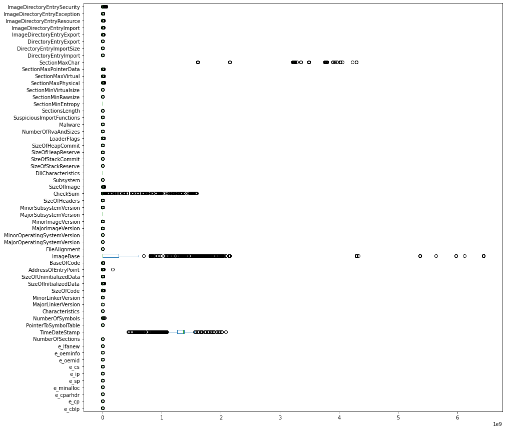

```python
#data.plot.hist(subplots = True, legend = True, layout = (14, 5), figsize = (20, 20));
data.plot.box(vert = False, figsize = (15, 15));
```

We still seem to a few number of outliers, but by this point we've dropped a lot of unnecessary features and we can continue to recursively do so (by doing the same 3 functions over and over again until we have a uranium ball of data). This ideal end state will never exist. It will be much more efficient leaving this kind of a job to PCA or RFE.

Additionally, given the size of the dataset, the chances of vectors being multicollinear are high. Therefore when using PCA, we will whiten our data; when using RFE we will also calculate the Variance Inflation Factor with a threshold of 5. Before committing to this however we should look at a heatmap of our features to understand where and to what extent the multicollinearity lies.

- RFE works by setting a subset of features to arrive at, then fitting a given ML algorithm to the dataset, ranking features by importance and discarding the least important ones, then refitting the model. This is recursively done until the specified number of features remain. It's Data-Driven-Darwinism!
- VIF regress all other vectors against one in a kind of one-versus-rest approach, using $R^2$ as a proxy value for how much one vector is collinear with another.

**Note that these are not the only methods we have for identifying and eliminating collinearity** - very, very elementary and simple mathematical approaches like the cosine between vectors or even monotonicity analyses will get us real far compared to these machine learning approaches.

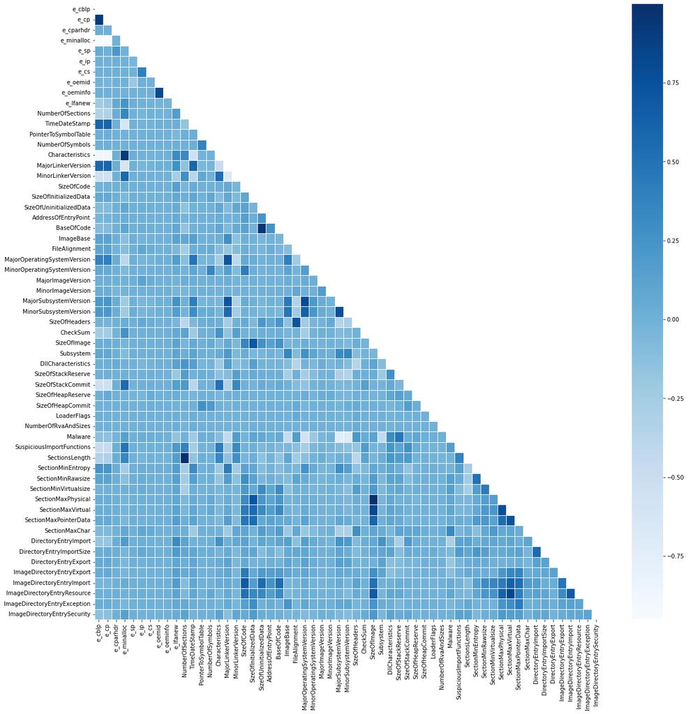

```python
# we have a lot of features so let's use only the lower triangle
fig, ax = plt.subplots(figsize=(20, 20))
sns.heatmap(data = data.corr(),
            cmap = "Blues",
            annot = False,
            linewidths = 0.5,
            mask = np.triu(data.corr()),
            ax = ax)
```

```python
X = data.drop(["Malware"], axis = 1)
y = data["Malware"]
X_pca, pca_varatio = standard_pca(stats.zscore(X))
```

```
--------------------
Variance Ratio:
--------------------

[0.12271752579545435, 0.10208125787463374, 0.07261785714345506, 0.04942402366770034, 0.03675012453903405, 0.035003887822308385, 0.03187046365243347, 0.028835022031623418, 0.027979846231178992, 0.025701593220199465, 0.023935629102351513, 0.021079075075299495, 0.02064990007272165, 0.020118442420659303…

--------------------
Variance Ratio sum:
--------------------

0.3835907890202775
```

```python
print("Sum to 25: ", sum(pca_varatio[0:25]))
print("Sum to 35: ", sum(pca_varatio[0:35]))

# we will use the first 33 values from our PCA set for further modelling.

# we will also whiten our PCA: Whitening multiplies component vectors by the
# square root of n_samples and then divided by the singular values to ensure
# uncorrelated outputs with unit component-wise variances.
```

```
Sum to 25:  0.8044728605007612
Sum to 35:  0.9199200260505238
```

```python
pca = PCA(n_components = 33, whiten = True)
X_pca = pca.fit_transform(stats.zscore(X))
sum(pca.explained_variance_ratio_)
```

```
0.9012961019022432
```

# Multi-modelling

## Model 1.1: PCA + Logit

```python
X_train_m1, X_test_m1, y_train_m1, y_test_m1 = prepare_data(X_pca, y, 0.30, 1337)

slogit = LogisticRegression()

slogit.fit(X_train_m1, y_train_m1)
pred_train_m1 = slogit.predict(X_train_m1)
pred_test_m1 = slogit.predict(X_test_m1)
```

```
X_train shape: (10196, 33)
X_test shape: (4371, 33)
```

```python
print("------------------------------------------------------------")
print("Training\n------------------------------------------------------------")
model_evaluation(y_train_m1, pred_train_m1)
print("Testing\n-------------------------------------------------------------")
model_evaluation(y_test_m1, pred_test_m1)
```

```
------------------------------------------------------------
Training
------------------------------------------------------------
Confusion Matrix :
```

|  | Predicted NO | Predicted YES |
| --- | --- | --- |
| Actual NO | 2028 | 176 |
| Actual YES | 67 | 7925 |

```
Report :
              precision    recall  f1-score   support

           0       0.97      0.92      0.94      2204
           1       0.98      0.99      0.98      7992

    accuracy                           0.98     10196
   macro avg       0.97      0.96      0.96     10196
weighted avg       0.98      0.98      0.98     10196


Accuracy Score : 0.9761671243624951
-------------------------------------------------------------
Testing
-------------------------------------------------------------
Confusion Matrix :
```

|  | Predicted NO | Predicted YES |
| --- | --- | --- |
| Actual NO | 860 | 85 |
| Actual YES | 33 | 3393 |

```
Report :
              precision    recall  f1-score   support

           0       0.96      0.91      0.94       945
           1       0.98      0.99      0.98      3426

    accuracy                           0.97      4371
   macro avg       0.97      0.95      0.96      4371
weighted avg       0.97      0.97      0.97      4371


Accuracy Score : 0.9730038892701899
-------------------------------------------------------------
```

```python
print("Coefficients:\n", slogit.coef_)
print("\nIntercept:\n", slogit.intercept_, "\n")
```

```
Coefficients:
 [[-1.68417931  2.01132681  3.39838114 -0.89727053 -0.58888974  0.35263635
   0.08425912  2.62610517  0.56228861 -2.03586982  1.01270696 -0.63819627
  -0.12222611 -0.57803976 -0.69609262  0.40898079  0.13053937  0.83476404
   0.31370946 -0.89889881 -0.26658079 -0.35194722  0.54854868  1.02405777
  -0.1545638  -0.52608552  0.14355318 -0.0835686   0.23559154 -0.36473714
   0.59050699 -1.72629782 -0.43331956]]

Intercept:
 [3.77801534]
```

## Model 1.2: PCA + Decision Tree Classifier

```python
sdtc = DecisionTreeClassifier(criterion = "entropy")  # max_depth = 10,

X_train_m2, X_test_m2, y_train_m2, y_test_m2 = prepare_data(X_pca, y, 0.30, 1337)

sdtc.fit(X_train_m2, y_train_m2)
pred_train_m2 = sdtc.predict(X_train_m2)
pred_test_m2 = sdtc.predict(X_test_m2)

print("\n")
print("------------------------------------------------------------")
print("Training\n------------------------------------------------------------")
model_evaluation(y_train_m2, pred_train_m2)
print("Testing\n-------------------------------------------------------------")
model_evaluation(y_test_m2, pred_test_m2)
```

```
X_train shape: (10196, 33)
X_test shape: (4371, 33)


------------------------------------------------------------
Training
------------------------------------------------------------
Confusion Matrix :
```

|  | Predicted NO | Predicted YES |
| --- | --- | --- |
| Actual NO | 2202 | 2 |
| Actual YES | 2 | 7990 |

```
Report :
              precision    recall  f1-score   support

           0       1.00      1.00      1.00      2204
           1       1.00      1.00      1.00      7992

    accuracy                           1.00     10196
   macro avg       1.00      1.00      1.00     10196
weighted avg       1.00      1.00      1.00     10196


Accuracy Score : 0.9996076892899176
-------------------------------------------------------------
Testing
-------------------------------------------------------------
Confusion Matrix :
```

|  | Predicted NO | Predicted YES |
| --- | --- | --- |
| Actual NO | 876 | 69 |
| Actual YES | 51 | 3375 |

```
Report :
              precision    recall  f1-score   support

           0       0.94      0.93      0.94       945
           1       0.98      0.99      0.98      3426

    accuracy                           0.97      4371
   macro avg       0.96      0.96      0.96      4371
weighted avg       0.97      0.97      0.97      4371


Accuracy Score : 0.9725463280713795
-------------------------------------------------------------
```

## Model 1.3: PCA + sklearn's Support Vector Classifier

```python
ssvc = SVC(kernel="linear", C=1, random_state=1337, probability = True)

X_train_m3, X_test_m3, y_train_m3, y_test_m3 = prepare_data(X_pca, y, 0.30, 1337)
ssvc.fit(X_train_m3, y_train_m3)
pred_train_m3 = ssvc.predict(X_train_m3)
pred_test_m3 = ssvc.predict(X_test_m3)

print("\n")
print("------------------------------------------------------------")
print("Training\n------------------------------------------------------------")
model_evaluation(y_train_m3, pred_train_m3)
print("Testing\n-------------------------------------------------------------")
model_evaluation(y_test_m3, pred_test_m3)
```

```
X_train shape: (10196, 33)
X_test shape: (4371, 33)


------------------------------------------------------------
Training
------------------------------------------------------------
Confusion Matrix :
```

|  | Predicted NO | Predicted YES |
| --- | --- | --- |
| Actual NO | 2026 | 178 |
| Actual YES | 61 | 7931 |

```
Report :
              precision    recall  f1-score   support

           0       0.97      0.92      0.94      2204
           1       0.98      0.99      0.99      7992

    accuracy                           0.98     10196
   macro avg       0.97      0.96      0.96     10196
weighted avg       0.98      0.98      0.98     10196


Accuracy Score : 0.9765594350725775
-------------------------------------------------------------
Testing
-------------------------------------------------------------
Confusion Matrix :
```

|  | Predicted NO | Predicted YES |
| --- | --- | --- |
| Actual NO | 860 | 85 |
| Actual YES | 30 | 3396 |

```
Report :
              precision    recall  f1-score   support

           0       0.97      0.91      0.94       945
           1       0.98      0.99      0.98      3426

    accuracy                           0.97      4371
   macro avg       0.97      0.95      0.96      4371
weighted avg       0.97      0.97      0.97      4371


Accuracy Score : 0.9736902310684054
-------------------------------------------------------------
```

## Model 2.1: RFE + Logit

```python
X_train_m5, X_test_m5, y_train_m5, y_test_m5 = prepare_data(X, y, 0.30, 1337)
X_train_m5 = stats.zscore(X_train_m5)
X_test_m5 = stats.zscore(X_test_m5)

rfe_slogit = LogisticRegression(max_iter = 200)

rfe = RFE(rfe_slogit, n_features_to_select = 15)
rfe = rfe.fit(X_train_m5, y_train_m5)

rfe_rank = pd.DataFrame()
rfe_rank["Features"] = X_train_m5.columns
rfe_rank["Support"] = rfe.support_
rfe_rank["Ranking"] = rfe.ranking_
rfe_rank = rfe_rank.sort_values(by = "Ranking", ascending = True)
rfe_rank
```

```
X_train shape: (10196, 58)
X_test shape: (4371, 58)
```

|  | Features | Support | Ranking |
| --- | --- | --- | --- |
| 28 | MajorSubsystemVersion | True | 1 |
| 14 | Characteristics | True | 1 |
| 23 | FileAlignment | True | 1 |
| 24 | MajorOperatingSystemVersion | True | 1 |
| 11 | TimeDateStamp | True | 1 |
| 30 | SizeOfHeaders | True | 1 |
| 15 | MajorLinkerVersion | True | 1 |
| 32 | SizeOfImage | True | 1 |
| 35 | SizeOfStackReserve | True | 1 |
| 43 | SectionMinEntropy | True | 1 |
| 47 | SectionMaxVirtual | True | 1 |
| 49 | SectionMaxChar | True | 1 |
| 1 | e_cp | True | 1 |
| 33 | Subsystem | True | 1 |
| 16 | MinorLinkerVersion | True | 1 |
| 3 | e_minalloc | False | 2 |
| 31 | CheckSum | False | 3 |
| 57 | ImageDirectoryEntrySecurity | False | 4 |
| 5 | e_ip | False | 5 |
| 6 | e_cs | False | 6 |
| 26 | MajorImageVersion | False | 7 |
| 34 | DllCharacteristics | False | 8 |
| 50 | DirectoryEntryImport | False | 9 |
| 29 | MinorSubsystemVersion | False | 10 |
| 18 | SizeOfInitializedData | False | 11 |
| 22 | ImageBase | False | 12 |
| 39 | LoaderFlags | False | 13 |
| 46 | SectionMaxPhysical | False | 14 |
| 42 | SectionsLength | False | 15 |
| 13 | NumberOfSymbols | False | 16 |
| 9 | e_lfanew | False | 17 |
| 53 | ImageDirectoryEntryExport | False | 18 |
| 20 | AddressOfEntryPoint | False | 19 |
| 55 | ImageDirectoryEntryResource | False | 20 |
| 54 | ImageDirectoryEntryImport | False | 21 |
| 52 | DirectoryEntryExport | False | 22 |
| 51 | DirectoryEntryImportSize | False | 23 |
| 21 | BaseOfCode | False | 24 |
| 41 | SuspiciousImportFunctions | False | 25 |
| 10 | NumberOfSections | False | 26 |
| 38 | SizeOfHeapCommit | False | 27 |
| 25 | MinorOperatingSystemVersion | False | 28 |
| 17 | SizeOfCode | False | 29 |
| 4 | e_sp | False | 30 |
| 2 | e_cparhdr | False | 31 |
| 27 | MinorImageVersion | False | 32 |
| 12 | PointerToSymbolTable | False | 33 |
| 56 | ImageDirectoryEntryException | False | 34 |
| 44 | SectionMinRawsize | False | 35 |
| 8 | e_oeminfo | False | 36 |
| 48 | SectionMaxPointerData | False | 37 |
| 7 | e_oemid | False | 38 |
| 40 | NumberOfRvaAndSizes | False | 39 |
| 37 | SizeOfHeapReserve | False | 40 |
| 36 | SizeOfStackCommit | False | 41 |
| 0 | e_cblp | False | 42 |
| 19 | SizeOfUninitializedData | False | 43 |
| 45 | SectionMinVirtualsize | False | 44 |

```python
rfe_cols = X_train_m5.columns[rfe.support_]
rfe_slogit.fit(X_train_m5[rfe_cols], y_train_m5)
pred_train_m5 = rfe_slogit.predict(X_train_m5[rfe_cols])
pred_test_m5 = rfe_slogit.predict(X_test_m5[rfe_cols])

print(pred_train_m5)
print(pred_test_m5)
```

```
[1 0 1 ... 0 1 1]
[1 1 0 ... 0 0 0]
```

```python
print("------------------------------------------------------------")
print("Training\n------------------------------------------------------------")
model_evaluation(y_train_m5, pred_train_m5)
print("Testing\n-------------------------------------------------------------")
model_evaluation(y_test_m5, pred_test_m5)
```

```
------------------------------------------------------------
Training
------------------------------------------------------------
Confusion Matrix :
```

|  | Predicted NO | Predicted YES |
| --- | --- | --- |
| Actual NO | 2013 | 191 |
| Actual YES | 67 | 7925 |

```
Report :
              precision    recall  f1-score   support

           0       0.97      0.91      0.94      2204
           1       0.98      0.99      0.98      7992

    accuracy                           0.97     10196
   macro avg       0.97      0.95      0.96     10196
weighted avg       0.97      0.97      0.97     10196


Accuracy Score : 0.9746959591996861
-------------------------------------------------------------
Testing
-------------------------------------------------------------
Confusion Matrix :
```

|  | Predicted NO | Predicted YES |
| --- | --- | --- |
| Actual NO | 863 | 82 |
| Actual YES | 27 | 3399 |

```
Report :
              precision    recall  f1-score   support

           0       0.97      0.91      0.94       945
           1       0.98      0.99      0.98      3426

    accuracy                           0.98      4371
   macro avg       0.97      0.95      0.96      4371
weighted avg       0.97      0.98      0.97      4371


Accuracy Score : 0.9750629146648364
-------------------------------------------------------------
```

### VIF gun-run one

```python
vif = pd.DataFrame()
vif["Features"] = X_train_m5[rfe_cols].columns
vif["VIF"] = [variance_inflation_factor(X_train_m5[rfe_cols].values, i) for i in range(X_train_m5[rfe_cols].shape[1])]
vif["VIF"] = round(vif["VIF"], 2)
vif = vif.sort_values(by = "VIF", ascending = False)
vif
```

|  | Features | VIF |
| --- | --- | --- |
| 3 | MajorLinkerVersion | 6.50 |
| 0 | e_cp | 5.85 |
| 2 | Characteristics | 5.83 |
| 7 | MajorSubsystemVersion | 5.69 |
| 6 | MajorOperatingSystemVersion | 3.87 |
| 13 | SectionMaxVirtual | 3.22 |
| 9 | SizeOfImage | 3.21 |
| 4 | MinorLinkerVersion | 2.63 |
| 5 | FileAlignment | 2.56 |
| 8 | SizeOfHeaders | 2.54 |
| 1 | TimeDateStamp | 2.13 |
| 14 | SectionMaxChar | 1.33 |
| 12 | SectionMinEntropy | 1.30 |
| 11 | SizeOfStackReserve | 1.28 |
| 10 | Subsystem | 1.21 |

```python
rfe_cols = rfe_cols.drop("MajorLinkerVersion")
```

```python
rfe_slogit.fit(X_train_m5[rfe_cols], y_train_m5)
pred_train_m5 = rfe_slogit.predict(X_train_m5[rfe_cols])
pred_test_m5 = rfe_slogit.predict(X_test_m5[rfe_cols])

print("------------------------------------------------------------")
print("Training\n------------------------------------------------------------")
model_evaluation(y_train_m5, pred_train_m5)
print("Testing\n-------------------------------------------------------------")
model_evaluation(y_test_m5, pred_test_m5)
```

```
------------------------------------------------------------
Training
------------------------------------------------------------
Confusion Matrix :
```

|  | Predicted NO | Predicted YES |
| --- | --- | --- |
| Actual NO | 2011 | 193 |
| Actual YES | 76 | 7916 |

```
Report :
              precision    recall  f1-score   support

           0       0.96      0.91      0.94      2204
           1       0.98      0.99      0.98      7992

    accuracy                           0.97     10196
   macro avg       0.97      0.95      0.96     10196
weighted avg       0.97      0.97      0.97     10196


Accuracy Score : 0.9736171047469596
-------------------------------------------------------------
Testing
-------------------------------------------------------------
Confusion Matrix :
```

|  | Predicted NO | Predicted YES |
| --- | --- | --- |
| Actual NO | 860 | 85 |
| Actual YES | 32 | 3394 |

```
Report :
              precision    recall  f1-score   support

           0       0.96      0.91      0.94       945
           1       0.98      0.99      0.98      3426

    accuracy                           0.97      4371
   macro avg       0.97      0.95      0.96      4371
weighted avg       0.97      0.97      0.97      4371


Accuracy Score : 0.9732326698695951
-------------------------------------------------------------
```

### VIF gun-run two

```python
vif = pd.DataFrame()
vif["Features"] = X_train_m5[rfe_cols].columns
vif["VIF"] = [variance_inflation_factor(X_train_m5[rfe_cols].values, i) for i in range(X_train_m5[rfe_cols].shape[1])]
vif["VIF"] = round(vif["VIF"], 2)
vif = vif.sort_values(by = "VIF", ascending = False)
vif
```

|  | Features | VIF |
| --- | --- | --- |
| 0 | e_cp | 5.78 |
| 2 | Characteristics | 5.76 |
| 6 | MajorSubsystemVersion | 4.36 |
| 5 | MajorOperatingSystemVersion | 3.85 |
| 12 | SectionMaxVirtual | 3.22 |
| 8 | SizeOfImage | 3.21 |
| 7 | SizeOfHeaders | 2.54 |
| 4 | FileAlignment | 2.52 |
| 1 | TimeDateStamp | 2.11 |
| 3 | MinorLinkerVersion | 1.71 |
| 13 | SectionMaxChar | 1.32 |
| 10 | SizeOfStackReserve | 1.22 |
| 9 | Subsystem | 1.21 |
| 11 | SectionMinEntropy | 1.19 |

```python
rfe_cols = rfe_cols.drop("e_cp")

rfe_slogit.fit(X_train_m5[rfe_cols], y_train_m5)
pred_train_m5 = rfe_slogit.predict(X_train_m5[rfe_cols])
pred_test_m5 = rfe_slogit.predict(X_test_m5[rfe_cols])

print("------------------------------------------------------------")
print("Training\n------------------------------------------------------------")
model_evaluation(y_train_m5, pred_train_m5)
print("Testing\n-------------------------------------------------------------")
model_evaluation(y_test_m5, pred_test_m5)
```

```
------------------------------------------------------------
Training
------------------------------------------------------------
Confusion Matrix :
```

|  | Predicted NO | Predicted YES |
| --- | --- | --- |
| Actual NO | 1973 | 231 |
| Actual YES | 76 | 7916 |

```
Report :
              precision    recall  f1-score   support

           0       0.96      0.90      0.93      2204
           1       0.97      0.99      0.98      7992

    accuracy                           0.97     10196
   macro avg       0.97      0.94      0.95     10196
weighted avg       0.97      0.97      0.97     10196


Accuracy Score : 0.969890153001177
-------------------------------------------------------------
Testing
-------------------------------------------------------------
Confusion Matrix :
```

|  | Predicted NO | Predicted YES |
| --- | --- | --- |
| Actual NO | 837 | 108 |
| Actual YES | 30 | 3396 |

```
Report :
              precision    recall  f1-score   support

           0       0.97      0.89      0.92       945
           1       0.97      0.99      0.98      3426

    accuracy                           0.97      4371
   macro avg       0.97      0.94      0.95      4371
weighted avg       0.97      0.97      0.97      4371


Accuracy Score : 0.9684282772820865
-------------------------------------------------------------
```

## Model 2.2: RFE + Decision Tree Classifier

```python
X_train_m6, X_test_m6, y_train_m6, y_test_m6 = prepare_data(X, y, 0.30, 1337)
X_train_m6 = stats.zscore(X_train_m6)
X_test_m6 = stats.zscore(X_test_m6)

rfe_sdtc = DecisionTreeClassifier(criterion = "gini", max_depth = 5)

rfe = RFE(rfe_sdtc, n_features_to_select = 15)
rfe = rfe.fit(X_train_m6, y_train_m6)

rfe_rank = pd.DataFrame()
rfe_rank["Features"] = X_train_m6.columns
rfe_rank["Support"] = rfe.support_
rfe_rank["Ranking"] = rfe.ranking_
rfe_rank = rfe_rank.sort_values(by = "Ranking", ascending = True)
rfe_rank
```

```
X_train shape: (10196, 58)
X_test shape: (4371, 58)
```

|  | Features | Support | Ranking |
| --- | --- | --- | --- |
| 57 | ImageDirectoryEntrySecurity | True | 1 |
| 34 | DllCharacteristics | True | 1 |
| 33 | Subsystem | True | 1 |
| 42 | SectionsLength | True | 1 |
| 56 | ImageDirectoryEntryException | True | 1 |
| 26 | MajorImageVersion | True | 1 |
| 25 | MinorOperatingSystemVersion | True | 1 |
| 24 | MajorOperatingSystemVersion | True | 1 |
| 22 | ImageBase | True | 1 |
| 21 | BaseOfCode | True | 1 |
| 20 | AddressOfEntryPoint | True | 1 |
| 11 | TimeDateStamp | True | 1 |
| 18 | SizeOfInitializedData | True | 1 |
| 16 | MinorLinkerVersion | True | 1 |
| 15 | MajorLinkerVersion | True | 1 |
| 17 | SizeOfCode | False | 2 |
| 38 | SizeOfHeapCommit | False | 3 |
| 41 | SuspiciousImportFunctions | False | 4 |
| 39 | LoaderFlags | False | 5 |
| 40 | NumberOfRvaAndSizes | False | 6 |
| 14 | Characteristics | False | 7 |
| 12 | PointerToSymbolTable | False | 8 |
| 43 | SectionMinEntropy | False | 9 |
| 13 | NumberOfSymbols | False | 10 |
| 44 | SectionMinRawsize | False | 11 |
| 55 | ImageDirectoryEntryResource | False | 12 |
| 47 | SectionMaxVirtual | False | 13 |
| 19 | SizeOfUninitializedData | False | 14 |
| 48 | SectionMaxPointerData | False | 15 |
| 51 | DirectoryEntryImportSize | False | 16 |
| 52 | DirectoryEntryExport | False | 17 |
| 54 | ImageDirectoryEntryImport | False | 18 |
| 23 | FileAlignment | False | 19 |
| 32 | SizeOfImage | False | 20 |
| 45 | SectionMinVirtualsize | False | 21 |
| 46 | SectionMaxPhysical | False | 22 |
| 53 | ImageDirectoryEntryExport | False | 23 |
| 49 | SectionMaxChar | False | 24 |
| 37 | SizeOfHeapReserve | False | 25 |
| 28 | MajorSubsystemVersion | False | 26 |
| 27 | MinorImageVersion | False | 27 |
| 50 | DirectoryEntryImport | False | 28 |
| 36 | SizeOfStackCommit | False | 29 |
| 29 | MinorSubsystemVersion | False | 30 |
| 35 | SizeOfStackReserve | False | 31 |
| 31 | CheckSum | False | 32 |
| 30 | SizeOfHeaders | False | 33 |
| 10 | NumberOfSections | False | 34 |
| 9 | e_lfanew | False | 35 |
| 8 | e_oeminfo | False | 36 |
| 7 | e_oemid | False | 37 |
| 6 | e_cs | False | 38 |
| 5 | e_ip | False | 39 |
| 4 | e_sp | False | 40 |
| 3 | e_minalloc | False | 41 |
| 2 | e_cparhdr | False | 42 |
| 1 | e_cp | False | 43 |
| 0 | e_cblp | False | 44 |

```python
rfe_cols = X_train_m6.columns[rfe.support_]
rfe_sdtc.fit(X_train_m6[rfe_cols], y_train_m6)
pred_train_m6 = rfe_sdtc.predict(X_train_m6[rfe_cols])
pred_test_m6 = rfe_sdtc.predict(X_test_m6[rfe_cols])

print(pred_train_m6)
print(pred_test_m6)
```

```
[1 0 1 ... 0 1 1]
[1 1 1 ... 1 1 1]
```

```python
print("------------------------------------------------------------")
print("Training\n------------------------------------------------------------")
model_evaluation(y_train_m6, pred_train_m6)
print("Testing\n-------------------------------------------------------------")
model_evaluation(y_test_m6, pred_test_m6)
```

```
------------------------------------------------------------
Training
------------------------------------------------------------
Confusion Matrix :
```

|  | Predicted NO | Predicted YES |
| --- | --- | --- |
| Actual NO | 2106 | 98 |
| Actual YES | 2 | 7990 |

```
Report :
              precision    recall  f1-score   support

           0       1.00      0.96      0.98      2204
           1       0.99      1.00      0.99      7992

    accuracy                           0.99     10196
   macro avg       0.99      0.98      0.99     10196
weighted avg       0.99      0.99      0.99     10196


Accuracy Score : 0.9901922322479404
-------------------------------------------------------------
Testing
-------------------------------------------------------------
Confusion Matrix :
```

|  | Predicted NO | Predicted YES |
| --- | --- | --- |
| Actual NO | 85 | 860 |
| Actual YES | 7 | 3419 |

```
Report :
              precision    recall  f1-score   support

           0       0.92      0.09      0.16       945
           1       0.80      1.00      0.89      3426

    accuracy                           0.80      4371
   macro avg       0.86      0.54      0.53      4371
weighted avg       0.83      0.80      0.73      4371


Accuracy Score : 0.8016472203157172
-------------------------------------------------------------
```

### VIF gun-run one

```python
vif = pd.DataFrame()
vif["Features"] = X_train_m6[rfe_cols].columns
vif["VIF"] = [variance_inflation_factor(X_train_m6[rfe_cols].values, i) for i in range(X_train_m6[rfe_cols].shape[1])]
vif["VIF"] = round(vif["VIF"], 2)
vif = vif.sort_values(by = "VIF", ascending = False)
vif
```

|  | Features | VIF |
| --- | --- | --- |
| 1 | MajorLinkerVersion | 4.10 |
| 7 | MajorOperatingSystemVersion | 2.57 |
| 5 | BaseOfCode | 2.31 |
| 4 | AddressOfEntryPoint | 2.27 |
| 2 | MinorLinkerVersion | 2.15 |
| 0 | TimeDateStamp | 1.61 |
| 6 | ImageBase | 1.43 |
| 12 | SectionsLength | 1.30 |
| 11 | DllCharacteristics | 1.25 |
| 10 | Subsystem | 1.21 |
| 13 | ImageDirectoryEntryException | 1.20 |
| 3 | SizeOfInitializedData | 1.18 |
| 14 | ImageDirectoryEntrySecurity | 1.08 |
| 8 | MinorOperatingSystemVersion | 1.06 |
| 9 | MajorImageVersion | 1.00 |

```python
rfe_cols = rfe_cols.drop("MajorLinkerVersion")

rfe_sdtc.fit(X_train_m6[rfe_cols], y_train_m6)
pred_train_m6 = rfe_sdtc.predict(X_train_m6[rfe_cols])
pred_test_m6 = rfe_sdtc.predict(X_test_m6[rfe_cols])

print("------------------------------------------------------------")
print("Training\n------------------------------------------------------------")
model_evaluation(y_train_m6, pred_train_m6)
print("Testing\n-------------------------------------------------------------")
model_evaluation(y_test_m6, pred_test_m6)
```

```
------------------------------------------------------------
Training
------------------------------------------------------------
Confusion Matrix :
```

|  | Predicted NO | Predicted YES |
| --- | --- | --- |
| Actual NO | 2106 | 98 |
| Actual YES | 2 | 7990 |

```
Report :
              precision    recall  f1-score   support

           0       1.00      0.96      0.98      2204
           1       0.99      1.00      0.99      7992

    accuracy                           0.99     10196
   macro avg       0.99      0.98      0.99     10196
weighted avg       0.99      0.99      0.99     10196


Accuracy Score : 0.9901922322479404
-------------------------------------------------------------
Testing
-------------------------------------------------------------
Confusion Matrix :
```

|  | Predicted NO | Predicted YES |
| --- | --- | --- |
| Actual NO | 85 | 860 |
| Actual YES | 6 | 3420 |

```
Report :
              precision    recall  f1-score   support

           0       0.93      0.09      0.16       945
           1       0.80      1.00      0.89      3426

    accuracy                           0.80      4371
   macro avg       0.87      0.54      0.53      4371
weighted avg       0.83      0.80      0.73      4371


Accuracy Score : 0.8018760009151223
-------------------------------------------------------------
```

### VIF gun-run two

```python
vif = pd.DataFrame()
vif["Features"] = X_train_m6[rfe_cols].columns
vif["VIF"] = [variance_inflation_factor(X_train_m6[rfe_cols].values, i) for i in range(X_train_m6[rfe_cols].shape[1])]
vif["VIF"] = round(vif["VIF"], 2)
vif = vif.sort_values(by = "VIF", ascending = False)
vif
```

|  | Features | VIF |
| --- | --- | --- |
| 4 | BaseOfCode | 2.31 |
| 3 | AddressOfEntryPoint | 2.27 |
| 6 | MajorOperatingSystemVersion | 1.80 |
| 0 | TimeDateStamp | 1.47 |
| 5 | ImageBase | 1.43 |
| 1 | MinorLinkerVersion | 1.40 |
| 11 | SectionsLength | 1.29 |
| 9 | Subsystem | 1.21 |
| 10 | DllCharacteristics | 1.20 |
| 12 | ImageDirectoryEntryException | 1.20 |
| 2 | SizeOfInitializedData | 1.18 |
| 13 | ImageDirectoryEntrySecurity | 1.07 |
| 7 | MinorOperatingSystemVersion | 1.05 |
| 8 | MajorImageVersion | 1.00 |

### Model 2.2: Observations

Singular trees with RFE underperform in the most surprising way. Precision, recall and f1 all take a pretty severe hit, and playing around with different tree depths and RFE features (10, 15; 10, 30; 5, 15; 5,30; 2, 15; 2, 30) indicate that a depth of 5 is ideal with more features being better. Additionally it appears that gini outperforms entropy as a measure of information gain. However with VIF there is a marginal improvement if we assume a VIF threshold of 3, though it's by no means good enough. Quite interesting once we look past the obvious implications of this behaviour.

# Conclusion

While we can identify malware using some extremely basic machine learning approaches, enhancing our work here with some mathematical and computational shortcuts will make our modelling much more targeted. For example, easier methods to identify collinearity exist as does prior work on malware identification given file headers - we don't need to use all of the features given to us because there are only a few things malware does differently. In fact, once we classify a program as malware, we can take the extra step and walk through the disassembled binary and see what kind of malicious behaviour it actually has, which could further help us by providing an avenue for clustering.

Reading disassembled malware is something I haven't done in a while, so the opportunity of rebooting into Kali from Arch sure is a juicy one!